# HiFi Full-length 16S Analysis Report

## Summary QC statistics

- Samples number: 44
- Final samples number post-DADA2: 44
- Missing samples (Not enough reads, do not pass QC, etc):
- Total number of CCS reads before filtering and primers trimming: 896502
- Was primers trimmed prior to DADA2? Yes
- Note that if downsampling was enabled, the reads will be filtered first, then restricted to a maximum of N reads.
- Total number of reads after quality filtering: 895523 (99.89%)
- Total number of reads after primers trimming (DADA2 input): 888641 (99.23%)
- Total number of ASVs found: 817
- Average number of ASVs per sample: 41
- Total number of reads in 817 ASVs: 598866 (67.39% of all input reads)

### Classification using VSEARCH with a single database

- ASVs classified at Species level: 658 (80.54%)
- Percentage reads belong to ASV classified at Species level: 99%
- ASVs classified at Genus level: 671 (82.13%)
- Percentage reads belong to ASV classified at Genus level: 99%

### Classification using Naive Bayes classifier with Greengenes2, GTDB and Silva

- ASVs classified at Species level: 773 (94.61%)
- Percentage reads belong to ASV classified at Species level: 99%
- ASVs classified at Genus level: 811 (99.27%)
- Percentage reads belong to ASV classified at Genus level: 100%

## Overall reads filtering and number of full-length reads

- Full-length reads are defined as reads with both F27 and R1492 primers
- Note that full length counts column will only show if cutadapt was used to trim primers (default).

|  | Sample | Reads before quality filter | Reads after quality filter | Full-length Reads | Full-length Reads Percent |
| --- | --- | --- | --- | --- | --- |
| 1 | NPT03 | 23186 | 23159 | 22991 | 0.9927458007685996 |
| 2 | NPT05 | 19210 | 19189 | 19048 | 0.9926520402313825 |
| 3 | NPT06 | 9702 | 9693 | 9621 | 0.9925719591457753 |
| 4 | NPT07 | 24700 | 24669 | 24449 | 0.9910819246828003 |
| 5 | NPT09 | 33279 | 33233 | 32973 | 0.9921764511178648 |
| 6 | NPT10 | 11467 | 11454 | 11365 | 0.9922297887200978 |
| 7 | NPT11 | 29665 | 29643 | 29386 | 0.9913301622642783 |
| 8 | NPT12 | 41522 | 41471 | 41122 | 0.991584480721468 |
| 9 | NPT13 | 42553 | 42508 | 42175 | 0.9921661804836737 |
| 10 | NPT14 | 15101 | 15091 | 14980 | 0.9926446226227553 |

[output cut: 34 more lines]

## Input reads QC (Before filtering and primers removal)

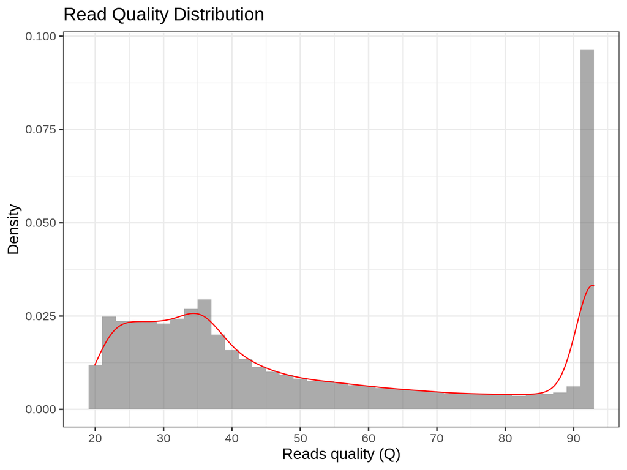

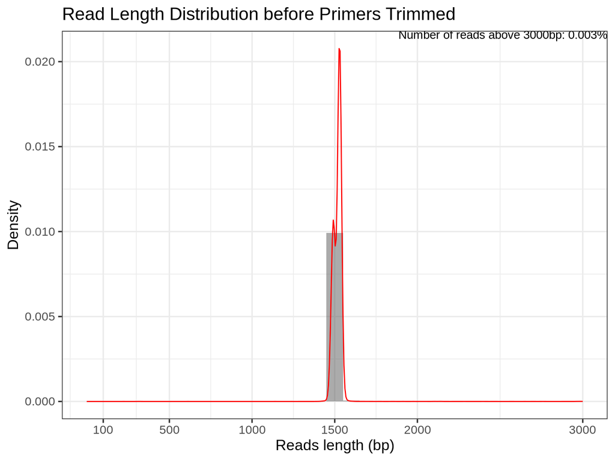

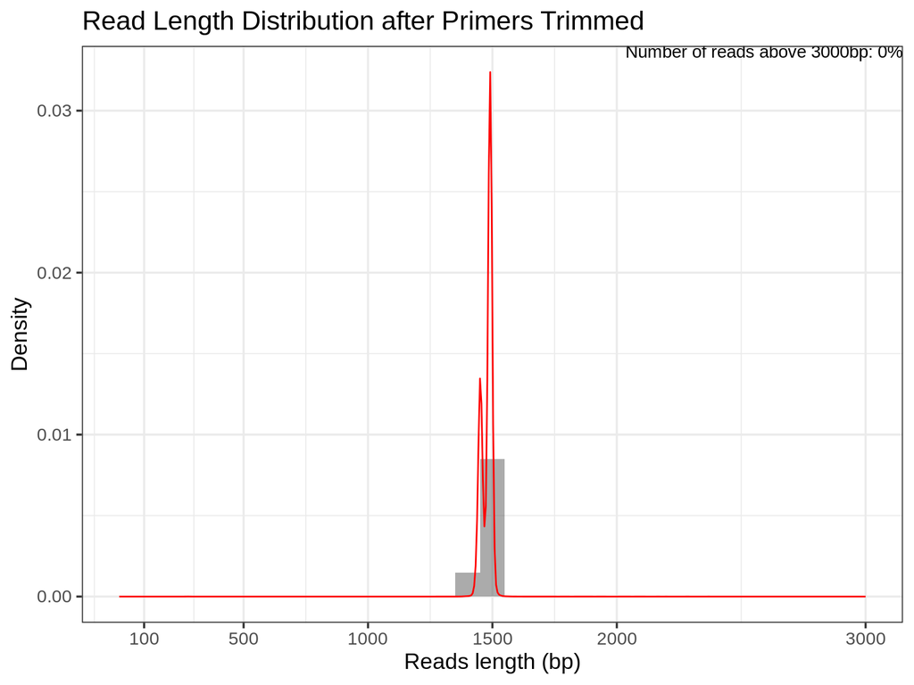

|  | Sample | Median Length (bp) | Median Read Quality | Length 1st Quartile (bp) | Length 3rd Quartile (bp) | Read Quality 1st Quartile (bp) | Read Quality 3rd Quartile (bp) |
| --- | --- | --- | --- | --- | --- | --- | --- |
| 1 | NPT03 | 1521 | 39.27 | 1489 | 1532 | 29.25 | 72.26 |
| 2 | NPT05 | 1532 | 46.42 | 1532 | 1532 | 32.9 | 88 |
| 3 | NPT06 | 1525 | 44.38 | 1524 | 1525 | 31.82 | 84.2 |
| 4 | NPT07 | 1525 | 40.98 | 1525 | 1526 | 30.47 | 75.75 |
| 5 | NPT09 | 1492 | 39.38 | 1491 | 1493 | 29.78 | 71.65 |
| 6 | NPT10 | 1532 | 45.81 | 1531 | 1532 | 32.34 | 88.09 |
| 7 | NPT11 | 1525 | 39.83 | 1524 | 1526 | 29.82 | 72.13 |
| 8 | NPT12 | 1525 | 41.56 | 1524 | 1532 | 30.24 | 79.42 |
| 9 | NPT13 | 1531 | 40.94 | 1525 | 1532 | 30.11 | 77.03 |
| 10 | NPT14 | 1528 | 41.85 | 1524 | 1532 | 30.22 | 81.51 |

[output cut: 34 more lines]

## DADA2 QC metrics

|  | sample-id | input | filtered | percentage of input passed filter | denoised | non-chimeric | percentage of input non-chimeric | n_ASV |
| --- | --- | --- | --- | --- | --- | --- | --- | --- |
| 1 | NPT03 | 22991 | 17688 | 76.93 | 14966 | 12211 | 53.11 | 79 |
| 2 | NPT05 | 19048 | 16062 | 84.32 | 16029 | 16007 | 84.04 | 12 |
| 3 | NPT06 | 9621 | 7919 | 82.31 | 7877 | 7665 | 79.67 | 17 |
| 4 | NPT07 | 24449 | 19569 | 80.04 | 19492 | 19432 | 79.48 | 12 |
| 5 | NPT09 | 32973 | 25952 | 78.71 | 22960 | 21533 | 65.3 | 76 |
| 6 | NPT10 | 11365 | 9403 | 82.74 | 9355 | 9354 | 82.31 | 22 |
| 7 | NPT11 | 29386 | 23113 | 78.65 | 23077 | 21811 | 74.22 | 17 |
| 8 | NPT12 | 41122 | 32621 | 79.33 | 32404 | 25964 | 63.14 | 15 |
| 9 | NPT13 | 42175 | 33299 | 78.95 | 32487 | 24014 | 56.94 | 17 |
| 10 | NPT14 | 14980 | 11849 | 79.1 | 11633 | 7847 | 52.38 | 25 |

[output cut: 34 more lines]

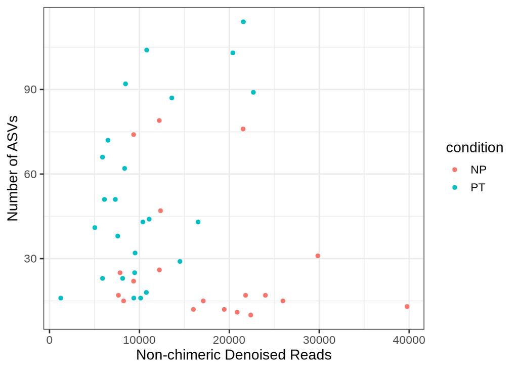

## Top Taxa and Plots

- For interactive view, use the Emperor QZV output from QIIME2 in `results/core-metrics-diversity` folder with QIIME2 View
- Note that if the distances between all samples are zero for a specific method, the plots will not be shown.
- MDS plots use ASVs as input.
- Samples might be missing due to choice of rarefecation depth. Rerun pipeline with `-resume --rarefaction_depth X` to choose a custom rarefaction depth X.

### Bray-Curtis MDS plot

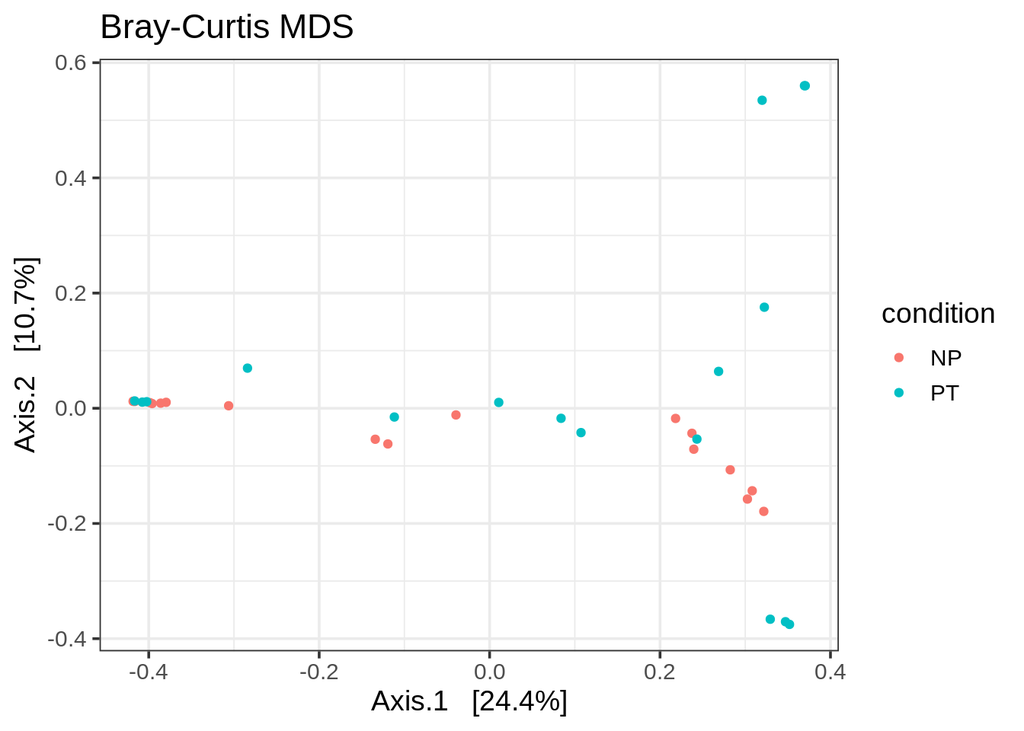

### Weighted and Unweighted Unifrac MDS plot

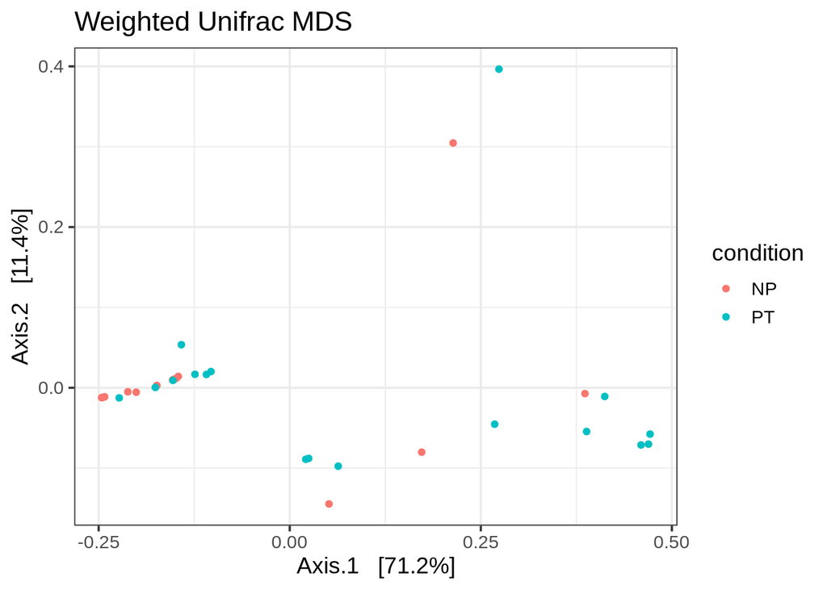

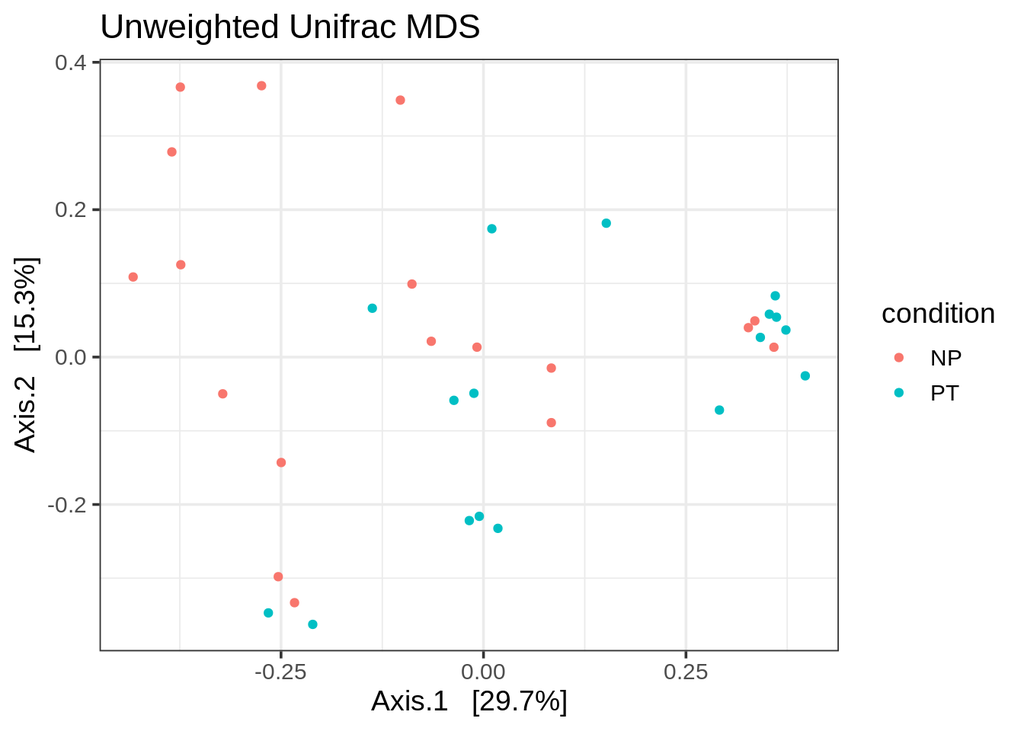

### Top 50 ASVs (VSEARCH classification)

|  | OTU | Kingdom | Phylum | Class | Order | Family | Genus | Species | NPT09 | NPT03 | NPT23 | NPT20 | NPT12 | NPT06 | NPT10 | NPT18 | NPT07 | NPT14 | NPT15 | NPT17 | NPT22 | NPT13 | NPT05 | NPT11 | NPT19 | NPT24 | NPT25 | PT01 | PT02 | … |
| --- | --- | --- | --- | --- | --- | --- | --- | --- | --- | --- | --- | --- | --- | --- | --- | --- | --- | --- | --- | --- | --- | --- | --- | --- | --- | --- | --- | --- | --- | --- |
| 1 | f53599c77b42f58a069415845eae4a6e | Bacteria | Bacillota | Bacilli | Lactobacillales | Lactobacillaceae | Lactobacillus | Lactobacillus iners | 24 | 3681 | 15 | 23567 | 4017 | 14 | 5464 | 24394 | 5 | 3413 | 302 | 234 | 11238 | 14743 | 15846 | 5 | 18852 | 39 | 3424 | 23 | 0 | … |
| 2 | 0dfcc8c06a2e792d466261b30e011612 | Bacteria | Bacillota | Bacilli | Lactobacillales | Lactobacillaceae | Lactobacillus | Lactobacillus crispatus | 0 | 0 | 1558 | 0 | 0 | 6 | 0 | 0 | 11354 | 0 | 24 | 0 | 19 | 0 | 0 | 1894 | 0 | 10536 | 0 | 0 | 0 | … |
| 3 | c8c246b9d8b0b3e2821b0e6384987d84 | Bacteria | Bacillota | Bacilli | Lactobacillales | Lactobacillaceae | Lactobacillus | Lactobacillus iners | 0 | 0 | 0 | 13766 | 4627 | 0 | 0 | 9 | 0 | 0 | 6 | 0 | 0 | 0 | 0 | 0 | 44 | 0 | 0 | 0 | 0 | … |
| 4 | d9ec7d04c7babde62706eb59b7cf5b0c | Bacteria | Bacillota | Bacilli | Lactobacillales | Lactobacillaceae | Lactobacillus | Lactobacillus jensenii | 0 | 0 | 0 | 1 | 15519 | 43 | 0 | 0 | 0 | 0 | 0 | 0 | 0 | 2 | 0 | 0 | 0 | 1 | 74 | 0 | 0 | … |
| 5 | 0a4a65fa27514181d94140679673d19d | Bacteria | Bacillota | Bacilli | Lactobacillales | Lactobacillaceae | Lactobacillus | Lactobacillus crispatus | 0 | 0 | 71 | 0 | 0 | 131 | 0 | 0 | 7827 | 0 | 0 | 0 | 4 | 2 | 0 | 542 | 0 | 4812 | 2445 | 0 | 0 | … |
| 6 | 6ff6b1bc190890de2412adae600b1e6e | Bacteria | Bacillota | Bacilli | Lactobacillales | Lactobacillaceae | Lactobacillus | Lactobacillus crispatus | 0 | 0 | 0 | 0 | 0 | 5726 | 1 | 0 | 0 | 3 | 0 | 0 | 5 | 0 | 0 | 6345 | 0 | 0 | 11 | 0 | 0 | … |
| 7 | d5eea2c589381aea49a11d423eeb2fdf | Bacteria | Actinomycetota | Actinomycetes | Actinomycetales | Bifidobacteriaceae | Bifidobacterium | Bifidobacterium leopoldii | 0 | 1280 | 0 | 0 | 0 | 3 | 0 | 0 | 0 | 0 | 0 | 0 | 0 | 0 | 0 | 0 | 0 | 0 | 0 | 0 | 9 | … |
| 8 | a112138136d14cbf62282f5b894e2c4a | Bacteria | Bacillota A | Clostridia | Lachnospirales | Lachnospiraceae | UBA629 | UBA629 sp005465875 | 9191 | 0 | 0 | 0 | 0 | 0 | 2 | 8 | 0 | 4 | 0 | 2 | 0 | 0 | 0 | 0 | 0 | 0 | 0 | 0 | 0 | … |
| 9 | 312dc4b399e6789dad4d43605c46744f | Bacteria | Actinomycetota | Actinomycetes | Actinomycetales | Bifidobacteriaceae | Bifidobacterium | Bifidobacterium leopoldii | 0 | 0 | 0 | 0 | 0 | 0 | 1 | 3 | 0 | 0 | 0 | 0 | 0 | 0 | 0 | 0 | 0 | 0 | 0 | 0 | 0 | … |
| 10 | 31a375ac2f7b2edae6f67d2a058fc6f7 | Bacteria | Bacillota | Bacilli | Lactobacillales | Lactobacillaceae | Lactobacillus | Lactobacillus iners | 36 | 0 | 0 | 0 | 0 | 0 | 0 | 0 | 0 | 0 | 0 | 0 | 0 | 0 | 0 | 0 | 0 | 0 | 0 | 0 | 0 | … |

[output cut: 40 more lines]

### Top 10 Classified Genus (Collapsed to species) with VSEARCH

- Relative abundance is calculated by dividing the number of reads for each ASV to the total number of reads in each sample.
- Heatmap contains only species with >1% abundance in at least 2 samples for the top 10 genus.

|  | Genus | Mean supporting reads across samples | Mean relative abundance across samples |
| --- | --- | --- | --- |
| 1 | Lactobacillus | 9140.59 | 0.58 |
| 2 | Bifidobacterium | 1564.05 | 0.13 |
| 3 | UBA629 | 676.34 | 0.06 |
| 4 | Prevotella | 670.34 | 0.05 |
| 5 | Streptococcus | 155.61 | 0.04 |
| 6 | Burkholderia | 206.59 | 0.02 |
| 7 | Klebsiella | 118.7 | 0.02 |
| 8 | Megasphaera C | 238.86 | 0.02 |
| 9 | Fannyhessea | 70.09 | 0.01 |
| 10 | KA00274 | 92.84 | 0.01 |

[output cut: 3 more lines]

|  | Genus | Species | NPT09 | NPT03 | NPT23 | NPT20 | NPT12 | NPT06 | NPT10 | NPT18 | NPT07 | NPT14 | NPT15 | NPT17 | NPT22 | NPT13 | NPT05 | NPT11 | NPT19 | NPT24 | NPT25 | PT01 | PT02 | PT03 | PT05 | PT04 | PT16 | PT06 | PT07 | … |
| --- | --- | --- | --- | --- | --- | --- | --- | --- | --- | --- | --- | --- | --- | --- | --- | --- | --- | --- | --- | --- | --- | --- | --- | --- | --- | --- | --- | --- | --- | --- |
| 1 | Lactobacillus | Lactobacillus crispatus | 0 | 0 | 8155 | 9 | 0 | 7153 | 1 | 5 | 19288 | 9 | 50 | 0 | 70 | 2 | 3 | 21781 | 0 | 20814 | 7524 | 4 | 0 | 15 | 2 | 0 | 4 | 1 | 0 | … |
| 2 | Lactobacillus | Lactobacillus gasseri | 2 | 4 | 0 | 0 | 0 | 0 | 0 | 0 | 0 | 3 | 98 | 6 | 0 | 0 | 0 | 11 | 1 | 0 | 0 | 0 | 7011 | 6259 | 1 | 5660 | 0 | 0 | 5 | … |
| 3 | Lactobacillus | Lactobacillus iners | 76 | 5632 | 15 | 39734 | 10176 | 15 | 8168 | 29408 | 5 | 4944 | 883 | 265 | 17034 | 17676 | 15923 | 6 | 22342 | 39 | 4473 | 23 | 0 | 693 | 1235 | 11 | 1331 | 6195 | 8322 | … |
| 4 | Lactobacillus | Lactobacillus jensenii | 0 | 0 | 0 | 1 | 15771 | 43 | 0 | 0 | 0 | 2408 | 2 | 0 | 0 | 6328 | 0 | 0 | 0 | 1 | 74 | 0 | 0 | 28 | 0 | 0 | 0 | 3095 | 0 | … |
| 5 | Lactobacillus | Lactobacillus mulieris | 2 | 0 | 0 | 0 | 0 | 0 | 0 | 0 | 0 | 0 | 0 | 5 | 0 | 0 | 0 | 0 | 0 | 0 | 0 | 0 | 2 | 24 | 0 | 0 | 0 | 0 | 0 | … |
| 6 | Lactobacillus | Lactobacillus paragasseri | 0 | 0 | 3 | 0 | 0 | 0 | 0 | 0 | 0 | 0 | 5764 | 0 | 0 | 0 | 56 | 0 | 0 | 0 | 0 | 0 | 0 | 0 | 0 | 0 | 2 | 0 | 0 | … |
| 7 | Bifidobacterium |  | 0 | 0 | 0 | 0 | 0 | 0 | 0 | 0 | 0 | 0 | 0 | 0 | 0 | 0 | 0 | 0 | 0 | 0 | 0 | 0 | 0 | 0 | 0 | 0 | 0 | 0 | 0 | … |
| 8 | Bifidobacterium | Bifidobacterium bifidum | 0 | 0 | 0 | 0 | 0 | 0 | 0 | 0 | 0 | 0 | 0 | 0 | 0 | 0 | 0 | 0 | 0 | 0 | 0 | 0 | 0 | 2 | 0 | 0 | 6 | 0 | 0 | … |
| 9 | Bifidobacterium | Bifidobacterium breve | 0 | 0 | 0 | 0 | 0 | 0 | 0 | 0 | 0 | 0 | 0 | 0 | 0 | 0 | 0 | 0 | 0 | 0 | 0 | 0 | 0 | 0 | 0 | 0 | 0 | 0 | 0 | … |
| 10 | Bifidobacterium | Bifidobacterium leopoldii | 0 | 1309 | 0 | 0 | 0 | 3 | 1 | 3 | 0 | 0 | 0 | 0 | 0 | 0 | 0 | 0 | 0 | 0 | 0 | 0 | 9 | 9 | 0 | 0 | 0 | 7 | 0 | … |

[output cut: 47 more lines]

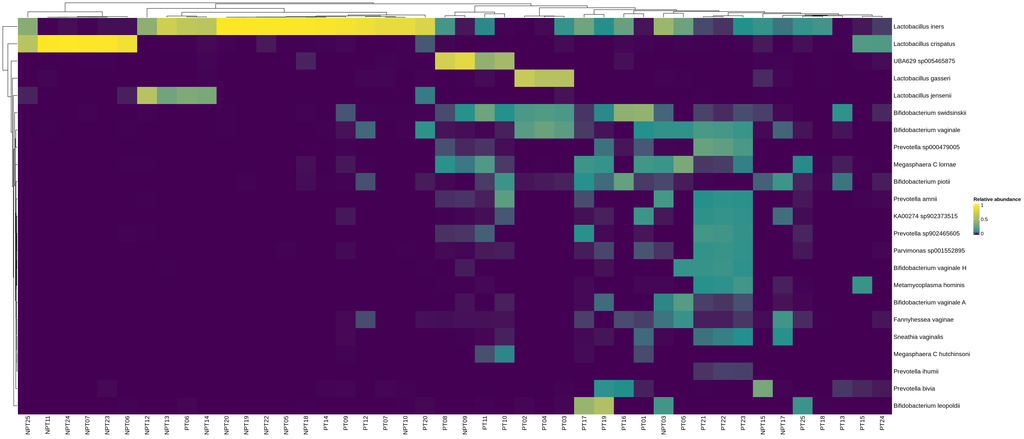

### Top 50 ASVs (Naive Bayes Classifier)

|  | OTU | Kingdom | Phylum | Class | Order | Family | Genus | Species | NPT09 | NPT03 | NPT23 | NPT20 | NPT12 | NPT06 | NPT10 | NPT18 | NPT07 | NPT14 | NPT15 | NPT17 | NPT22 | NPT13 | NPT05 | NPT11 | NPT19 | NPT24 | NPT25 | PT01 | PT02 | … |
| --- | --- | --- | --- | --- | --- | --- | --- | --- | --- | --- | --- | --- | --- | --- | --- | --- | --- | --- | --- | --- | --- | --- | --- | --- | --- | --- | --- | --- | --- | --- |
| 1 | f53599c77b42f58a069415845eae4a6e | Bacteria | Bacillota I | Bacilli A | Lactobacillales | Lactobacillaceae | Lactobacillus | Lactobacillus iners | 24 | 3681 | 15 | 23567 | 4017 | 14 | 5464 | 24394 | 5 | 3413 | 302 | 234 | 11238 | 14743 | 15846 | 5 | 18852 | 39 | 3424 | 23 | 0 | … |
| 2 | 0dfcc8c06a2e792d466261b30e011612 | Bacteria | Bacillota I | Bacilli A | Lactobacillales | Lactobacillaceae | Lactobacillus | Lactobacillus crispatus | 0 | 0 | 1558 | 0 | 0 | 6 | 0 | 0 | 11354 | 0 | 24 | 0 | 19 | 0 | 0 | 1894 | 0 | 10536 | 0 | 0 | 0 | … |
| 3 | c8c246b9d8b0b3e2821b0e6384987d84 | Bacteria | Bacillota I | Bacilli A | Lactobacillales | Lactobacillaceae | Lactobacillus | Lactobacillus iners | 0 | 0 | 0 | 13766 | 4627 | 0 | 0 | 9 | 0 | 0 | 6 | 0 | 0 | 0 | 0 | 0 | 44 | 0 | 0 | 0 | 0 | … |
| 4 | d9ec7d04c7babde62706eb59b7cf5b0c | Bacteria | Bacillota I | Bacilli A | Lactobacillales | Lactobacillaceae | Lactobacillus | Lactobacillus jensenii | 0 | 0 | 0 | 1 | 15519 | 43 | 0 | 0 | 0 | 0 | 0 | 0 | 0 | 2 | 0 | 0 | 0 | 1 | 74 | 0 | 0 | … |
| 5 | 0a4a65fa27514181d94140679673d19d | Bacteria | Bacillota I | Bacilli A | Lactobacillales | Lactobacillaceae | Lactobacillus | Lactobacillus crispatus | 0 | 0 | 71 | 0 | 0 | 131 | 0 | 0 | 7827 | 0 | 0 | 0 | 4 | 2 | 0 | 542 | 0 | 4812 | 2445 | 0 | 0 | … |
| 6 | 6ff6b1bc190890de2412adae600b1e6e | Bacteria | Bacillota I | Bacilli A | Lactobacillales | Lactobacillaceae | Lactobacillus | Lactobacillus crispatus | 0 | 0 | 0 | 0 | 0 | 5726 | 1 | 0 | 0 | 3 | 0 | 0 | 5 | 0 | 0 | 6345 | 0 | 0 | 11 | 0 | 0 | … |
| 7 | d5eea2c589381aea49a11d423eeb2fdf | Bacteria | Actinomycetota | Actinobacteria | Bifidobacteriales | Bifidobacteriaceae | Gardnerella | Gardnerella vaginalis | 0 | 1280 | 0 | 0 | 0 | 3 | 0 | 0 | 0 | 0 | 0 | 0 | 0 | 0 | 0 | 0 | 0 | 0 | 0 | 0 | 9 | … |
| 8 | a112138136d14cbf62282f5b894e2c4a | Bacteria | Bacillota A 368345 | Clostridia 258483 | Lachnospirales | Lachnospiraceae | UBA629 | UBA629 sp005465875 | 9191 | 0 | 0 | 0 | 0 | 0 | 2 | 8 | 0 | 4 | 0 | 2 | 0 | 0 | 0 | 0 | 0 | 0 | 0 | 0 | 0 | … |
| 9 | 312dc4b399e6789dad4d43605c46744f | Bacteria | Actinomycetota | Actinobacteria | Bifidobacteriales | Bifidobacteriaceae | Gardnerella | Gardnerella vaginalis | 0 | 0 | 0 | 0 | 0 | 0 | 1 | 3 | 0 | 0 | 0 | 0 | 0 | 0 | 0 | 0 | 0 | 0 | 0 | 0 | 0 | … |
| 10 | 31a375ac2f7b2edae6f67d2a058fc6f7 | Bacteria | Bacillota I | Bacilli A | Lactobacillales | Lactobacillaceae | Lactobacillus | Lactobacillus iners | 36 | 0 | 0 | 0 | 0 | 0 | 0 | 0 | 0 | 0 | 0 | 0 | 0 | 0 | 0 | 0 | 0 | 0 | 0 | 0 | 0 | … |

[output cut: 40 more lines]

### Top 10 Classified Genus (Collapsed to species) with Naive Bayes Classifier

- Relative abundance is calculated by dividing the number of reads for each ASV to the total number of reads in each sample.
- Heatmap contains only species with >1% abundance in at least 2 samples for the top 10 genus.

|  | Genus | Mean supporting reads across samples | Mean relative abundance across samples |
| --- | --- | --- | --- |
| 1 | Lactobacillus | 9158.95 | 0.58 |
| 2 | Gardnerella | 1058.55 | 0.09 |
| 3 | Prevotella | 686.3 | 0.06 |
| 4 | UBA629 | 680.23 | 0.06 |
| 5 | Streptococcus | 155.61 | 0.04 |
| 6 | Bifidobacterium 388775 | 299.32 | 0.03 |
| 7 | Megasphaera C | 268.45 | 0.03 |
| 8 | Bifidobacterium | 209.82 | 0.02 |
| 9 | Klebsiella 724518 | 118.7 | 0.02 |
| 10 | Burkholderia-Caballeronia-Paraburkholderia | 155.91 | 0.01 |

[output cut: 6 more lines]

|  | Genus | Species | NPT09 | NPT03 | NPT23 | NPT20 | NPT12 | NPT06 | NPT10 | NPT18 | NPT07 | NPT14 | NPT15 | NPT17 | NPT22 | NPT13 | NPT05 | NPT11 | NPT19 | NPT24 | NPT25 | PT01 | PT02 | PT03 | PT05 | PT04 | PT16 | PT06 | PT07 | … |
| --- | --- | --- | --- | --- | --- | --- | --- | --- | --- | --- | --- | --- | --- | --- | --- | --- | --- | --- | --- | --- | --- | --- | --- | --- | --- | --- | --- | --- | --- | --- |
| 1 | Lactobacillus | Lactobacillus crispatus | 0 | 0 | 8155 | 9 | 0 | 7153 | 1 | 5 | 19328 | 9 | 58 | 0 | 70 | 2 | 3 | 21781 | 0 | 20814 | 7563 | 4 | 0 | 23 | 2 | 0 | 4 | 1 | 0 | … |
| 2 | Lactobacillus | Lactobacillus iners | 76 | 5640 | 15 | 39734 | 10176 | 15 | 8168 | 29408 | 5 | 4944 | 883 | 265 | 17034 | 17633 | 15923 | 6 | 22342 | 39 | 4473 | 23 | 0 | 693 | 1235 | 11 | 1355 | 6195 | 8388 | … |
| 3 | Lactobacillus | Lactobacillus jensenii | 0 | 0 | 0 | 1 | 15771 | 43 | 0 | 0 | 0 | 2408 | 2 | 0 | 0 | 6328 | 0 | 0 | 0 | 1 | 74 | 0 | 0 | 28 | 0 | 0 | 0 | 3095 | 0 | … |
| 4 | Lactobacillus | Lactobacillus mulieris | 2 | 0 | 0 | 0 | 0 | 0 | 0 | 0 | 0 | 0 | 0 | 5 | 0 | 0 | 0 | 0 | 0 | 0 | 0 | 0 | 2 | 0 | 0 | 0 | 0 | 0 | 0 | … |
| 5 | Lactobacillus | Lactobacillus paragasseri | 2 | 4 | 3 | 0 | 0 | 0 | 0 | 0 | 0 | 3 | 5862 | 6 | 0 | 0 | 56 | 11 | 1 | 0 | 0 | 0 | 7011 | 6228 | 1 | 5660 | 2 | 0 | 5 | … |
| 6 | Lactobacillus | Unclassified | 0 | 0 | 0 | 0 | 0 | 0 | 0 | 0 | 0 | 0 | 7 | 0 | 0 | 43 | 0 | 0 | 0 | 0 | 25 | 0 | 0 | 67 | 0 | 0 | 0 | 0 | 0 | … |
| 7 | Gardnerella | Gardnerella vaginalis | 1024 | 2035 | 0 | 3 | 7 | 3 | 2 | 63 | 6 | 0 | 287 | 1098 | 0 | 0 | 0 | 0 | 5 | 0 | 0 | 3596 | 1365 | 1421 | 206 | 1427 | 3795 | 7 | 2 | … |
| 8 | Gardnerella | Unclassified | 0 | 0 | 0 | 0 | 0 | 0 | 0 | 0 | 0 | 0 | 0 | 0 | 0 | 0 | 0 | 0 | 0 | 0 | 0 | 0 | 0 | 0 | 0 | 0 | 0 | 0 | 0 | … |
| 9 | Prevotella | Prevotella amnii | 231 | 1396 | 0 | 0 | 2 | 0 | 0 | 0 | 0 | 0 | 0 | 0 | 0 | 0 | 0 | 0 | 0 | 0 | 0 | 0 | 0 | 0 | 0 | 0 | 0 | 0 | 0 | … |
| 10 | Prevotella | Prevotella bivia | 0 | 0 | 9 | 0 | 0 | 0 | 4 | 1 | 0 | 0 | 3664 | 5 | 0 | 0 | 0 | 0 | 0 | 0 | 0 | 62 | 0 | 3 | 0 | 0 | 219 | 0 | 8 | … |

[output cut: 44 more lines]

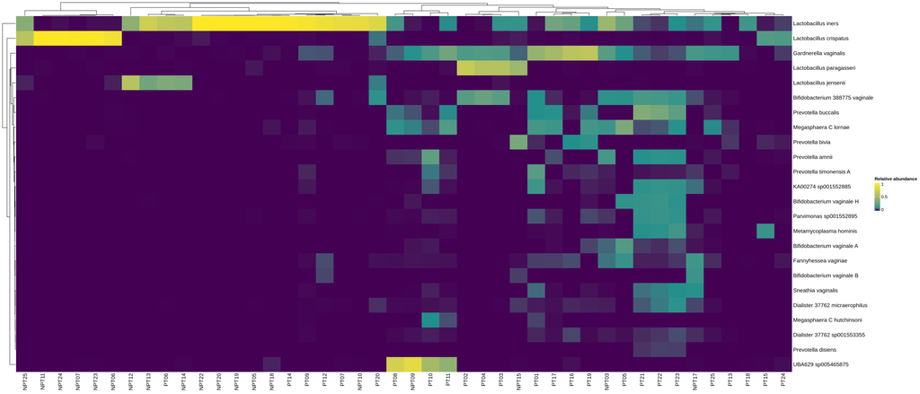